# Learning about random effects with simulation

# Modelling non-linear relationships

One of the assumptions of simple linear regression (or generalized-linear regression like logistic regression) is that an assumption is made about the relationship between each predictor and the outcome- that it is ‘linear’. Figuring out when to allow this assumption to be broken is a much debated statistical dilemma: on one hand, if there is a true non-linear relationship, then making a linear assumption is an example of **model-mispsecification**. On the other hand, we often have noisey or sparse data, and fitting data too closely leads to **over-fitting**.

## Introducing the delta model

In this RMarkdown, I’ll use **simulation** to show my solution to this problem, which I call a **delta model**. The delta model is different than most spline models because instead of smoothing over the values of the outcome as the predictor variable changes, it smoothes over the rates of change of the outcome as the predictor changes. The concept of modelling rates of change s called ‘differencing’ and is used in models like ARIMA. The delta model is different in that it is still modelling the value of the outcome, but it smooths the rate of change of the outcome with respect to the predictor.

This model has several nice features:

1. Nested within it are the two most extreme cases of a predictor-outcome relationship
   - The case of perfect linear relationship
   - The case of no relationship
2. It mathematically represents a common real **data-generating process**, that the slope of the predictor-outcome relationship for a given value of the predictor is related to slopes of nearby predictor values
   - Most non-linear models represent cases where the value of the outcome for a given value of the predictor is related to the value of the outcome for nearby predictor values
3. It naturally regularizes, in other words it uses the observed data to estimate how non-linear the relationship should be.

# Simulating the delta model

## 1. Statistical definition of the model

### 1.a Starting with linear regression and the ‘broken stick’ model

Recall that in linear regression, we estimate the rate of change of $y$ as $x_1$ changes; this value is the slope parameter $\beta_1$*. This enforces the assumption that the relationship between $y$ and $x_1$ is linear. What if we thought that the relationship between $y$ and $x_1$ changed at some point. The point where we let the slope change is called a **knot**. We would have two slope parameters, $\beta_{1,1}$ and $\beta_{1,2}$, where the relationship of $y$ and $x_1$ is $\beta_{1,1}$ when $x_1<knot$ and is $\beta_{1,2}$ when $x_1>=knot$. This is called a “broken stick” model, and it’s often referred to as the simplest spline.

#### 1.aa Simulating broken stick data

Let’s simulate data based on this model, and plot it. II’ll use the steps I previously outlined to create a simulation.

First I’ll make some fake observations in the `x_i` vector, and two slope parameters held in the `beta_k` vector. I’m going to say the knot is set where $x_1=1$

```r
n_obs <- 1000
##sy: first simulate a continuous variable x1
x_1 <- rnorm(n_obs)

##sy: create 2 beta parameters, I'm just picking two random values
beta_k <- c(0.5, 2.5)
```

##### 1.aaa Introducing an aggregator design matrix

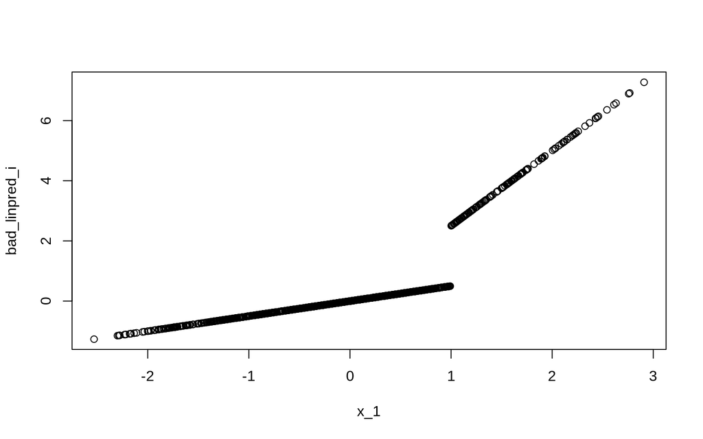

```r
##sy: calculate the true linear predictor using the wrong approach
bad_linpred_i <- ifelse(x_1 < 1, x_1 * beta_k[1], x_1 * beta_k[2])

p<-plot(x_1, bad_linpred_i)
```

Notice the discontinuity. We need to account for the domain of $x_1$ where the relationship was different. I’ll use an **aggregator** matrix to solve this problem. This is a matrix that sums up the effect of all segments preceeding a value of $x_1$ to arrive at the effect of $y$ given a specific value of $x_1$. Here’s how we would calculate $y$ if $x_1=1$:

```r
A_ik = matrix(nrow = n_obs, ncol = 2)

##sy: first column is x_1 if x_1<knot, otherwise equal to knot
A_ik[, 1] = ifelse(x_1 < 1, x_1, 1)

##sy: second column is 0 if x_1<knot, otherwise equal to x_1-knot
A_ik[, 2] = ifelse(x_1 < 1, 0, x_1 - 1)
```

Let’s look at some rows of `A_ik` where $x_1<knot$:

```r
head(A_ik[x_1 < 1, ])
```

```
##            [,1] [,2]
## [1,] -0.4858303    0
## [2,] -0.5701435    0
## [3,] -0.8621215    0
## [4,] -0.5602268    0
## [5,] -0.6180490    0
## [6,]  0.7962160    0
```

And now for some rows where $x_1>=knot$:

```r
head(A_ik[x_1 >= 1, ])
```

```
##      [,1]       [,2]
## [1,]    1 0.59779825
## [2,]    1 1.90908921
## [3,]    1 0.19201128
## [4,]    1 1.75690412
## [5,]    1 0.05515891
## [6,]    1 0.74020753
```

And now let’s calculate $y$ using this design matrix, and plot the result:

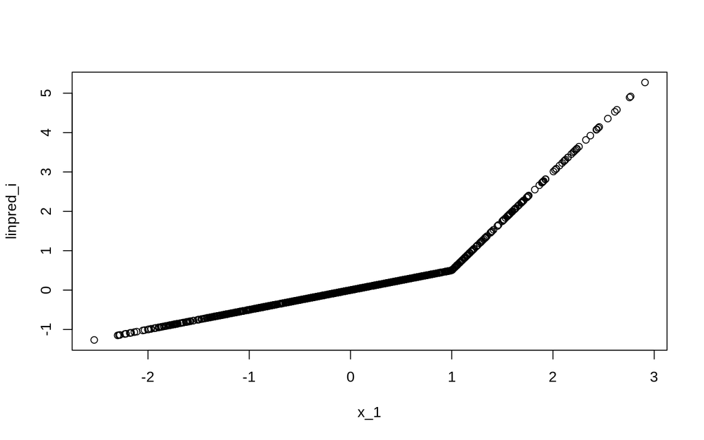

```r
linpred_i <- A_ik %*% beta_k

plot(x_1, linpred_i)
```

If this is confusing, think through some examples and do the simple algebra yourself to intuit what’s going on.

As a last step, I’ll add some stochastic noise to get our simulated observed data, stored in the `obs_i` vector. Then I’ll plot `x_i` against `obs_i`

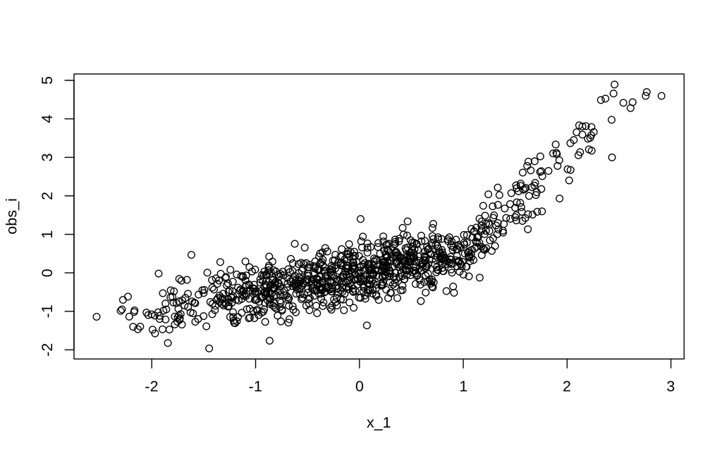

```r
##sy: add some stochastic noise
obs_i <- linpred_i + rnorm(n_obs, mean = 0, sd = 0.4)

p<-plot(x_1, obs_i)
```

#### 1.ac Fitting a broken stick model

We could run a model capturing this unique relationship in $y$ and $x_1$. But how would I create a design matrix such that I would fit two betas for a single predictor variable?

but there are a couple issues with implementing a “broken stick” model:

1. What if we think there are more than one places where the relationship between $y$ and $x_1$ should change? Only allowing the slope to change at a single point is a completely arbitrary decision, and those decisions typically lead to **model mis-specification**.
2. Even if we don’t have other predictor variables that muddy up our data, we don’t usually have a good sense of where the relationship should change. Deciding where the cut point should be is another arbitrary decision.
3. There is no relationship between $\beta_{1,1}$ and $\beta_{1,2}$.

### 1.b Generalizing to the linear spline

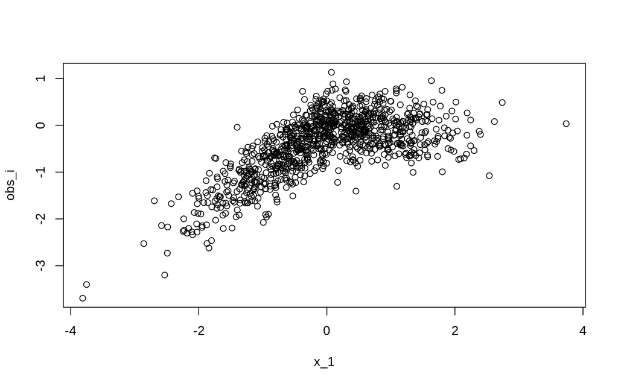

```r
n_obs <- 1000
n_knots <- 10
##sy: first simulate a continuous variable X_1
x_1 <- rnorm(n_obs)

##sy: create 10 beta parameters
betas <- rnorm(10)

##sy: calculate the true linear predictor using the broken stick approach
##sy: make a design matrix
linpred_i <- ifelse(x_1 < mean(x_1), x_1 * betas[1], x_1 * betas[2])

##sy: add some stochastic noise
obs_i <- linpred_i + rnorm(n_obs, mean = 0, sd = 0.4)

p<-plot(x_1, obs_i)
```

As mentioned, the delta model smoothes over the rate of change of the outcome, let’s call it $y$, as some continuous predictor variable, let’s call it $x_1$ changes.

*For those who like calculus, $\beta_1$ can be thought of as the partial derivative of $y$ given $x_1$: $\frac{\delta y}{\delta x}$. I like thinking in terms of the basic algebra underlying calculus, so that’s how I present this model.

Simon Yadgir

2019-04-15